```python
import dependencies
from IPython.display import display, HTML
from heat_pump import MEAWHeatPumpSystem
from heat_pump import EnergyEstimationM1
```

# RAMING VAN HET ENERGIEVERBRUIK VAN EEN LUCHT/WATER-WARMTEPOMPSYSTEEM MET DE BINMETHODE

## Systeemconfiguratie: warmtepompsysteem met watervertrektemperatuur 55 °C (W55)

**1. Het warmtepompsysteem wordt in het computerprogramma gecreëerd.**

```python
mehp = MEAWHeatPumpSystem()
```

**2. De parameters om de warmtebelastingskarakteristiek van het gebouw te berekenen, worden aan het computerprogramma doorgegeven.**

```python
mehp.set_heat_load_line(
    Q_cond_des=10.321,   # kW
    Q_vent_des=0.928,    # kW
    Q_dhw_des=0.759,     # kW
    T_outside_bal=16.0,  # °C
    T_outside_des=-8.0,  # °C
    T_room_des=20.385,   # °C
    eff_inst=0.9
)
```

**3. Het *csv*-bestand met de prestatietabel van de warmtepomp wordt aan het computerprogramma doorgegeven. De prestatietabel is geldig voor een watervertrektemperatuur van 55 °C.**

```python
mehp.set_heat_pump_performance('../datafiles/hp_W55.csv')
```

**4. Het computerprogramma kan de karakteristieken nu tekenen.**

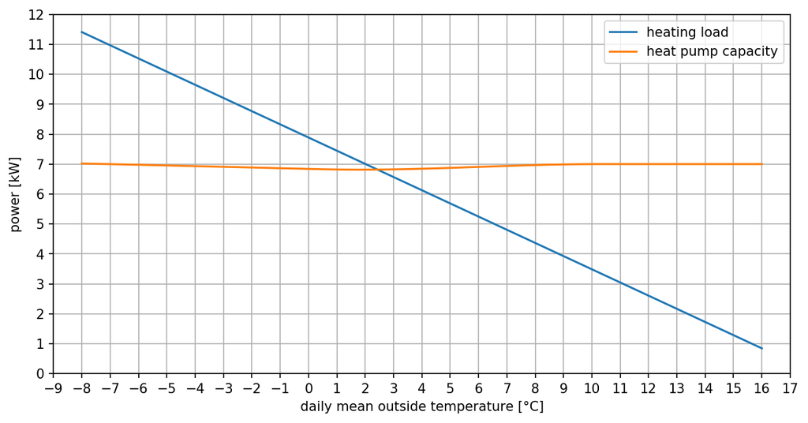

```python
graph = mehp.plot_characteristics(fig_size=(10, 5), dpi=150)
graph.show_graph()
```

**5. De bivalentietemperatuur van het systeem gebouw + warmtepomp:**

```python
display(HTML(f"Bivalentietemperatuur = <b>{mehp.get_heat_pump_balance_point():.2f}</b> °C"))
```

Bivalentietemperatuur = **2.43** °C